# Robot Juggling

In this assignment you will learn how to control a robot to juggle a ball. To achieve this goal, you will program a velocity controlled robot, such that it causes the ball to bounce with some desired periodic motion. Specifically, you will implement a hybrid controller that uses a *mirror control law* within the framework of Box 2D, a 2D physics simulator.

This assignment will be broken into the following components:

1. Robot Juggling Demo

   a. Box 2D Simulator
2. PD-Control of a robot

   a. Reference and Error signals

   b. Implementing P-controller

   c. Implementing a PD-controller
3. Robot Juggling

   a. Ball Dynamics (projectile) b. Ball dynamics with collision c. Mirror control law

# Robot Juggling Demo

The following code will run the instructor's solution of the juggling demo. Try not to look at the instructor's code until after completing the assignment!

[figure not shown]

If a window pops up like the picture then you have successfully run the demo. So what exactly are you looking at? As mentioned previously we are simulating the physics using Box2D.

However, the window that popped up is merely a visulazation of the simulator that uses pygame. Pygame is a software package used to create games in python. It allows the use of keyboard and mouse input. For example, if you hit 'q' or 'esc' the window should close. *Note: in OS X the window may not close, however the simulation will stop.*

The visulazation is showing an instance of robot juggling.

- The **robot** is a dark rectangular paddle.
- The **ball** is a magenta circle bouncing up and down
- The yellow and red horizontal bars show the desired heights.
  - The upper yellow bar shows the desired peak height of the ball
  - The lower red bar shows the desired impact location for the ball and the paddle.
- The ground is the green rectangle. It is a static object. Ideally your ball will never touch the ground!

### Reference frames

All of the objects has a local reference frame located in the center of its body.

Our fixed frame is an interial reference frame with $\hat{x}$ increasing to the right and $\hat{y}$ increasing upwards. The origin is located in the bottom left corner.

### Simulation

All of the objects listed above are *rigid bodies* that (approximately) obey the laws of physics $\vec{F} = m \vec{a}$. By definition, rigid bodies are not able to penetrate one another.

For our purpose, it's important to know that the physics simulator will approximate the state of the world and can have errors in numerical accuracy.

# PD- Control of a robot

In this section you will control the paddle to move to a desired location. The robot is velocity controlled. This means that for every time step, you can specify the robot's linear velocity in x and y. Additionally you can specify the robot's angular velocity.

The goal is to program the robot to move to a desired location specified by $\vec{x}^* = (x,y,\theta)$ by specifing the velocity at each time step.

We will break this into a few steps.

1. Running the simulation and accessing the robot state information
2. Open loop control of the robot
3. Feedback control of the robot

### PD Control Part 1: Running the simulation and accessing the robot state information

The following code will show a simple example of running the simulator

You should see the robot (paddle) start in the middle of the screen and fall down due to gravity.

**Activity: Change the robot's orientation and rerun the simulation**

```python
from gui_b2d import GuiB2D
from create_planar_world import createPlanarWorld

# Start the gui
screen_size = (640, 480)
sim_size = (32, 24)
fps = 60
time_step = 1.0/fps
gui = GuiB2D(screen_size, sim_size, fps)
gui.start()

# Create a line juggling world
world, bodies, cl = createPlanarWorld(gravity=9.81)
robot = bodies['robot']

# set robot position to middle of screen
robot.position = (16,  12)
# update the orientation of te robot
robot.angle = 0

# run the simulation
while gui.running:
    world.Step(time_step, 10,10)
    gui.draw(world)
#close the window (doesn't work in mac)
gui.stop()
```

### PD Control Part 1: Running the simulation and accessing the robot state information continued

Let's rerun our simulation and find plot the vertical position of the robot over time.

We can construct a graph using the matplotlib package.

**Activity: There seems to be a bug in the code. Can you find it?**

```
Done!
```

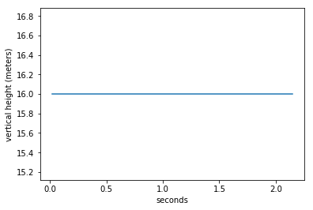

```python
import matplotlib.pyplot as plt

gui = GuiB2D(screen_size, sim_size, fps)
gui.start()
world, bodies, cl = createPlanarWorld(gravity=9.81)
robot = bodies['robot']

# set robot position to middle of screen
robot.position = (16,  12)

# create arrays to hold the xtime, y values
poses = []
times = []

t= 0
while gui.running:
    world.Step(time_step, 10,10)
    t+= time_step
    poses.append(robot.position[0]) # keep track of y only
    times.append(t)
    gui.draw(world)
gui.stop()

print('Done!')
plt.close()
plt.plot(times, poses)
plt.xlabel("seconds")
plt.ylabel("vertical height (meters)")
plt.show()
```

### PD Control Part 2:Open loop control of the robot

Now we are going to move our robot using velocity control.

we can update the linear velocity of the robot using

```
robot.linearVelocity = (0, 1)  # this will make the robot move upwards
robot.angularVelocity = 0
```

**Activity: program the robot to move to position (16, 15) using open loop commands. How close can you get?**

```
Done!
```

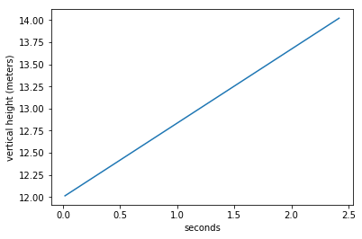

```python
gui = GuiB2D(screen_size, sim_size, fps)
gui.start()
world, bodies, cl = createPlanarWorld(gravity=9.81)
robot = bodies['robot']

# set robot position to middle of screen
robot.position = (16,  12)

# create arrays to hold the xtime, y values
poses = []
times = []

t= 0


while gui.running:

    # update the robot's velocity
    robot.linearVelocity= (0, 1)

    world.Step(time_step, 10,10)
    t+= time_step
    poses.append(robot.position[1]) # keep track of y only
    times.append(t)
    gui.draw(world)

gui.stop()

print('Done!')
plt.close()
plt.plot(times, poses)
plt.xlabel("seconds")
plt.ylabel("vertical height (meters)")
plt.show()
```

**ActivitieS:**

1. Try using different gains. See if you can observe different system response behavior, such as:
   - under damped
   - damped
   - overdamped
2. Improve upon your controller by adding a derivative term.

```python
# PD Control Part 3
```

```
Done!
```

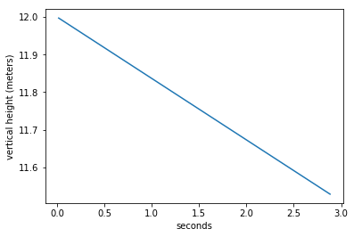

```python
gui = GuiB2D(screen_size, sim_size, fps)
gui.start()
world, bodies, cl = createPlanarWorld(gravity=9.81)
robot = bodies['robot']

# set robot position to middle of screen
robot.position = (16,  12)

# create arrays to hold the xtime, y values
poses = []
times = []
t= 0

desired_pose = (16, 12, 15)

def apply_control():
    u_x = 0
    u_y = 0
    u_th = 0
    robot.linearVelocity = (u_x, u_y)
    robot.angularVelocity = (u_th)

while gui.running:

    # update the robot's velocity
    apply_control()

    world.Step(time_step, 10,10)
    t+= time_step
    poses.append(robot.position[1]) # keep track of y only
    times.append(t)
    gui.draw(world)

gui.stop()

print('Done!')
plt.close()
plt.plot(times, poses)
plt.xlabel("seconds")
plt.ylabel("vertical height (meters)")
plt.show()
```

### PD Control Part 3: Feedback control of the robot

You can access the current state information of the robot using:

```
robot.position
robot.angle
```

You can control the robot using velocity commands:

```
robot.linearVelocity = (vx, vy)
robot.angularVelocity = (theta_dot)
```

Create a simple position controller that can move the robot to a desired $(x,y,\theta)$ location using a simple control law:

$$u = K_{pose}*(pose_{desired} - pose_{current}$$

```python
from Box2D import *
from gui_b2d import GuiB2D
import numpy as np
from create_planar_world import createPlanarWorld

peak_height = 20.0
impact_height = 10.0

restitution = .0
gravity = 9.81

x_center = 10
x_goal_posts = 25

Kp_mirror = 1.45
Kp_robot = 1.1
Kd_robot = 0.02

init_poses = {

    'robot': (x_center, impact_height-1),
    'ground': (0, 1),
    'boundsL': (x_goal_posts, impact_height ),
    'boundsU': (x_goal_posts, peak_height ),
    'ball': (x_center, peak_height ),

}

def createTransform(x,y,th, isPose=True):
    c = np.cos(th)
    s = np.sin(th)
    if isPose:
        z = 1.
    else:
        z = 0.
    T = np.matrix( [[c,-s,x],
                    [s, c, y],
                    [0.,0.,z]])
    return T

def poseFromTransform(T):
    x = T[0,2]
    y = T[1,2]
    c = T[0,0]
    s = T[1,0]
    th = np.arctan2(s,c)
    return (x,y,th)

def transformPose((x,y,th), T, isPose=True):
    T_pose = createTransform (x,y,th,isPose)
    T_new = T*T_pose
    return poseFromTransform(T_new)

def transformState( (pose, vel), T):
    pose = transformPose(pose, T, isPose=True)
    vel = transformPose(vel, T, isPose=False)
    return pose, vel


# create inertial reference frame
T_ref_to_world = createTransform(x_center, impact_height, 0)
T_world_to_ref = np.linalg.inv(T_ref_to_world)
T_eye = np.eye(3)
```

```python
def reset(bodies, cl):
    for body, pos in init_poses.items():
        bodies[body].position = b2Vec2(pos)
        bodies[body].angle = 0
        bodies[body].linearVelocity = b2Vec2(0,0)
        bodies[body].angularVelocity = 0

    cl.updateState(transformState( getState(bodies['ball']), T_ref_to_world))

    bodies['ball'].restitution = restitution
    #bodies['robot'].restitution = restitution
    return bodies, cl

def getState(body):
    x,y = body.position
    th = body.angle
    xdot, ydot = body.linearVelocity
    thdot = body.angularVelocity
    pose = (x,y,th)
    vel = (xdot,ydot,thdot)

    pose,vel = transformState((pose,vel), T_world_to_ref )
    return pose,vel


def getEnergy(body, body_state):
    (x,y,th), (vx,vy,vth) = body_state
    v = (vx**2 + vy**2)**0.5
    ke = 0.5*body.mass*(v**2)
    pe = body.mass*y*gravity
    return ke + pe
```

```python
def applyControl(robot, x_desired, smooth=0.9):

    e_pos, e_vel = np.array(x_desired) - np.array(getState(robot))
    ux, uy, uth = Kp_robot*e_pos + Kd_robot*e_vel

    prev_vel = robot.linearVelocity
    prev_ang = robot.angularVelocity
    k_curr = smooth
    k_prev = 1 - smooth
    computed_vel = k_prev*prev_vel + k_curr*b2Vec2(ux, uy)

    robot.linearVelocity = np.clip(computed_vel, -20, 20)
    robot.angularVelocity =k_prev*prev_ang + k_curr*uth


def ballEnergy(ball, cl):
    ball_state = transformState(cl.ball_state, T_world_to_ref)
    energy = getEnergy(ball, ball_state)
    return energy

def controlLaw(ball, cl, desired_energy):
    x, xdot = getState(ball)

    b = x[1]
    bdot = xdot[1]

    energy_error =  desired_energy - getEnergy(ball, getState(ball))

    k_rest =  (1 - restitution)/(1 + restitution)
    k_energy = Kp_mirror*energy_error
    gain = (k_rest +  k_energy)



    r = np.clip(-gain*b, -10, 11)
    rdot = np.clip(-gain*bdot , -20, 20)

    control_pos = (0, r, 0)
    control_vel = (0, rdot, 0)
    return control_pos, control_vel
```

```python
gui = GuiB2D( (640, 640), (32, 24), 60)
gui.start()
world, bodies, cl = createPlanarWorld(gravity)
bodies, cl = reset(bodies, cl)

robot = bodies['robot']
ball = bodies['ball']
desired_energy = getEnergy(ball, getState(ball))  #ballEnergy(ball,cl)

print ball.mass
while gui.running:
#for i in range(100):
    applyControl(robot, controlLaw(ball, cl, desired_energy))
    world.Step(1.0/gui.FPS, 10,10)
    gui.draw(world)


gui.stop()
print('Done!')
```

```
0.0785398185253
Done!
```